# Consensus clustering

2020

*Adapted from Childhood Cancer Data Lab, Alex’s Lemonade Stand Foundation [training materials](https://github.com/AlexsLemonade/training-modules/tree/ddc9c76e03aaf147fb2f011490ea6aec835de064)*

## Background

In this notebook, we’ll cluster RNA-seq data from the Open Pediatric Brain Tumor Atlas (OpenPBTA) project and create a heatmap. OpenPBTA is a collaborative project organized by the CCDL and the Center for Data-Driven Discovery in Biomedicine (D3b) at the Children’s Hospital of Philadelphia conducted openly on GitHub.

You can read more about the project [here](https://github.com/alexslemonade/openpbta-analysis/#openpbta-analysis).

We’ve downloaded the publicly available data from the project and have performed some transformation and filtering steps in preparation for the workshop. You can find more information about these upstream processing steps in `setup/README.md`.

In this workshop, we will use data from medulloblastoma samples. Medulloblastoma is the most common cancerous brain tumor in children ([ref](https://www.mayoclinic.org/diseases-conditions/medulloblastoma/cdc-20363524)) and there have been four subtypes identified in children ([ref](https://www.cancer.gov/rare-brain-spine-tumor/tumors/medulloblastoma)).

If we want to identify groups or clusters using expression data, we often want to **validate** those groups in some way, such as determining the “correct” number of groups or checking for agreement within clusters.

In this notebook, we’ll use the medulloblastoma data from the OpenPBTA project to demonstrate a technique for cluster validation and look how clusters overlap with sample labels that are available in our metadata.

## Set up

### Libraries

```r
library(tidyverse)
# Consensus clustering library
library(ConsensusClusterPlus)
```

### Files

```r
# Molecular subtype labels, etc.
clinical_metadata_file <- file.path("data",
                                    "pbta-medullo-histologies.tsv.gz")

# Processed RNA-seq data
rnaseq_file <- file.path("data", "pbta-medullo-vst-collapsed.tsv.gz")
```

## Read in and prepare data

Our sample metadata and the RNA-seq data we’ve processed ahead of time are stored in TSV files.

```r
clinical_df <- read_tsv(clinical_metadata_file)
rnaseq_df <- read_tsv(rnaseq_file)
```

These RNA-seq data have already been transformed using variance-stabilizing transformation such that the variance is less dependent on the mean count values (which are influenced by factors such as the length or size of a gene) and the values should be on a more similar, log2-like scale. Transformation like this is recommended when we are using clustering or distances.

### Some notes on how expression data are stored

Gene expression data are typically stored where rows are genes (features) and columns are samples. This is in contrast to many other applications, where rows are samples and columns are the features being measured.

Here’s an example from the [`palmerpenguins` package](https://allisonhorst.github.io/palmerpenguins/index.html).

```r
head(palmerpenguins::penguins)
```

| species | island | bill_length_mm | bill_depth_mm | flipper_length_mm | body_mass_g | sex | year |
| --- | --- | --- | --- | --- | --- | --- | --- |
| Adelie | Torgersen | 39.1 | 18.7 | 181 | 3750 | male | 2007 |
| Adelie | Torgersen | 39.5 | 17.4 | 186 | 3800 | female | 2007 |
| Adelie | Torgersen | 40.3 | 18.0 | 195 | 3250 | female | 2007 |
| Adelie | Torgersen | NA | NA | NA | NA | NA | 2007 |
| Adelie | Torgersen | 36.7 | 19.3 | 193 | 3450 | female | 2007 |
| Adelie | Torgersen | 39.3 | 20.6 | 190 | 3650 | male | 2007 |

And here’s our RNA-seq data frame:

```r
head(rnaseq_df)
```

| gene_symbol | BS_09Z7TC35 | BS_1AYRM596 | BS_1BWP5MCT | BS_1QXEC43H | BS_1TWCV047 | BS_2SFTWNVE | BS_2Z1MKS84 | BS_3BDAG9YN | BS_3F5PR9GS | BS_3MYEMXPQ | BS_3NWQXPQV | BS_3V3KE3VT | BS_44A3ES23 | BS_4CP4T22V | BS_4D9DD103 | BS_4PH1MBGR | BS_4W68NV3M | BS_5PJCHF6V | BS_5VQP0E6K | BS_61E80SD6 | BS_77317DY4 | BS_7C40TRCY | BS_7FWZ518S | BS_7XQRH69M | BS_81SP2HX4 | BS_8GW1TMV2 | BS_8T7DZV2F | BS_9M5XJ10G | BS_9NJHQE9F | … |
| --- | --- | --- | --- | --- | --- | --- | --- | --- | --- | --- | --- | --- | --- | --- | --- | --- | --- | --- | --- | --- | --- | --- | --- | --- | --- | --- | --- | --- | --- | --- |
| 5_8S_rRNA | 3.328461 | 3.328461 | 3.328461 | 3.328461 | 3.328461 | 3.328461 | 3.328461 | 3.328461 | 3.328461 | 3.328461 | 3.328461 | 3.328461 | 3.328461 | 3.328461 | 3.328461 | 3.328461 | 3.328461 | 3.328461 | 3.328461 | 3.328461 | 3.328461 | 3.328461 | 3.328461 | 3.328461 | 3.328461 | 3.328461 | 3.328461 | 3.328461 | 3.328461 | … |
| 5S_rRNA | 3.711513 | 3.328461 | 3.328461 | 3.328461 | 3.328461 | 3.328461 | 3.703283 | 3.328461 | 3.328461 | 3.328461 | 3.328461 | 3.328461 | 3.328461 | 3.328461 | 3.328461 | 3.328461 | 3.789634 | 3.328461 | 3.328461 | 3.328461 | 3.328461 | 3.328461 | 3.328461 | 3.328461 | 3.328461 | 3.328461 | 3.328461 | 3.328461 | 3.816721 | … |
| 7SK | 10.923788 | 12.834533 | 11.596220 | 12.159553 | 12.014188 | 10.923687 | 11.002848 | 8.995484 | 11.435197 | 12.380123 | 11.646883 | 10.592039 | 11.049654 | 11.738154 | 11.873009 | 11.143161 | 12.528074 | 11.030978 | 10.798556 | 10.979055 | 12.689290 | 11.548458 | 11.691429 | 11.853589 | 11.920823 | 9.227397 | 7.827321 | 11.655818 | 11.687942 | … |
| A1BG | 8.845778 | 7.711605 | 9.734178 | 9.169774 | 7.517938 | 6.464044 | 8.853039 | 8.791830 | 9.073189 | 5.202310 | 7.525081 | 7.317690 | 7.415327 | 5.526052 | 9.341713 | 6.544334 | 6.927785 | 5.338928 | 8.776140 | 5.355845 | 9.516433 | 8.251517 | 7.255058 | 7.683060 | 8.736676 | 8.565035 | 8.476541 | 7.956967 | 7.730936 | … |
| A1BG-AS1 | 8.825524 | 7.585883 | 8.982287 | 8.498395 | 7.822335 | 7.401299 | 8.897057 | 9.062943 | 9.267571 | 4.560853 | 5.437253 | 7.141801 | 7.004719 | 5.368718 | 9.098012 | 6.099834 | 6.927785 | 4.920089 | 9.027372 | 5.584258 | 9.653093 | 8.803789 | 7.545670 | 7.774434 | 8.105286 | 9.029957 | 8.674574 | 8.298886 | 7.649615 | … |
| A1CF | 3.988115 | 3.328461 | 3.328461 | 3.328461 | 3.328461 | 4.090059 | 3.328461 | 3.328461 | 3.328461 | 3.775753 | 3.786851 | 3.954078 | 3.328461 | 3.328461 | 3.680205 | 3.687272 | 3.977941 | 3.328461 | 3.328461 | 3.328461 | 3.328461 | 3.766783 | 4.155996 | 3.757220 | 3.328461 | 3.328461 | 3.328461 | 3.752300 | 3.328461 | … |

We’ll sometimes want to transpose our RNA-seq data such that features are columns and rows are samples when working with “generic” packages.

We’re using a package (`ConsensusClusterPlus`) that is explicitly designed for working with gene expression or transcriptomics data, so this is the orientation that it expects.

From the package documentation, the data to be clustered should be:

> a data matrix where columns=items/samples and rows are features. For example, a gene expression matrix of genes in rows and microarrays in columns,

One other thing you may have noticed about the penguins data is that there are categorical variables like species labels stored alongside the numeric features.

```r
head(palmerpenguins::penguins)
```

| species | island | bill_length_mm | bill_depth_mm | flipper_length_mm | body_mass_g | sex | year |
| --- | --- | --- | --- | --- | --- | --- | --- |
| Adelie | Torgersen | 39.1 | 18.7 | 181 | 3750 | male | 2007 |
| Adelie | Torgersen | 39.5 | 17.4 | 186 | 3800 | female | 2007 |
| Adelie | Torgersen | 40.3 | 18.0 | 195 | 3250 | female | 2007 |
| Adelie | Torgersen | NA | NA | NA | NA | NA | 2007 |
| Adelie | Torgersen | 36.7 | 19.3 | 193 | 3450 | female | 2007 |
| Adelie | Torgersen | 39.3 | 20.6 | 190 | 3650 | male | 2007 |

When storing gene expression data in a tabular format, usually the sample attributes (e.g., disease type, any kind of sample label!) are stored *separately*.

```r
head(clinical_df)
```

| Kids_First_Biospecimen_ID | short_histology | broad_histology | tumor_descriptor | molecular_subtype |
| --- | --- | --- | --- | --- |
| BS_09Z7TC35 | Medulloblastoma | Embryonal tumor | Recurrence | Group3 |
| BS_1AYRM596 | Medulloblastoma | Embryonal tumor | Initial CNS Tumor | Group4 |
| BS_1BWP5MCT | Medulloblastoma | Embryonal tumor | Initial CNS Tumor | Group3 |
| BS_1QXEC43H | Medulloblastoma | Embryonal tumor | Progressive | SHH |
| BS_1TWCV047 | Medulloblastoma | Embryonal tumor | Initial CNS Tumor | Group3 |
| BS_2SFTWNVE | Medulloblastoma | Embryonal tumor | Initial CNS Tumor | Group4 |

Check that samples are in the same order using the biospecimen identifiers.

```r
identical(colnames(rnaseq_df)[-1], clinical_df$Kids_First_Biospecimen_ID)
```

```
[1] TRUE
```

We’ll need a matrix for our next steps.

```r
rnaseq_mat <- rnaseq_df %>%
  column_to_rownames("gene_symbol") %>%
  as.matrix()
```

## Cluster validation

### Consensus clustering

The method we’ll use to examine the stability of clusters is called consensus clustering. Consensus clustering aims to finds the “consensus” across multiple runs of the algorithm using a resampling procedure.

We’ll use the package [`ConsensusClusterPlus`](https://bioconductor.org/packages/release/bioc/html/ConsensusClusterPlus.html) that we loaded up top ([vignette](https://bioconductor.org/packages/release/bioc/vignettes/ConsensusClusterPlus/inst/doc/ConsensusClusterPlus.pdf)).

The consensus clustering methodology was first introduced in [Monti *et al.* (2003)](https://doi.org/10.1023/A:1023949509487) Let’s look at some simulated data and results from this publication to see what consensus clustering results look like in an ideal case where we know how many clusters there are!

Consensus clustering outputs something called a *consensus index* that tells us how often two samples are clustered together over multiple runs of the algorithm (0 = never, 1 = always). The consensus index values can be visualized in a consensus matrix. Here’s a consensus matrix from simulated data with three groups. Because this shows the relationship between samples, rows *and* columns correspond to samples. A cell will be white if the consensus index = 0 and red if the consensus index = 1.

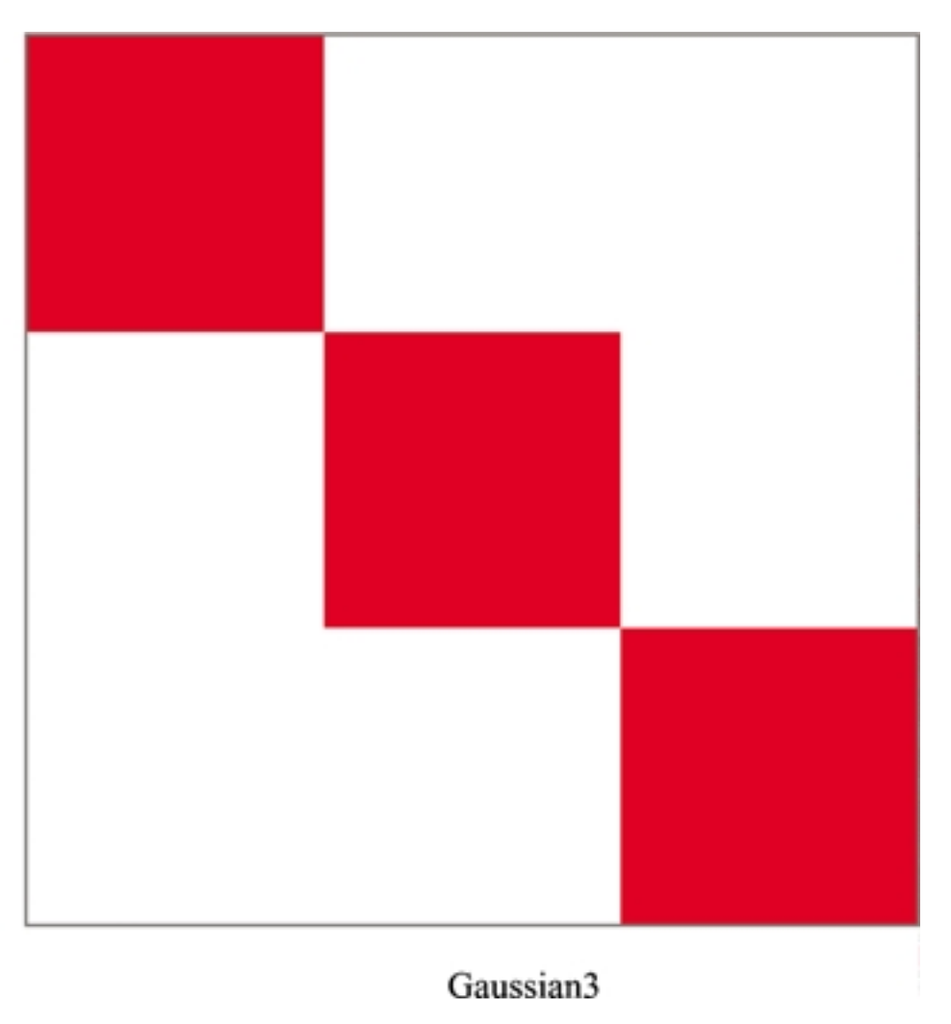

There are 3 groups or clusters, represented by the 3 red blocks on the diagonal, of samples that always cluster together and never cluster with samples outside of that cluster.

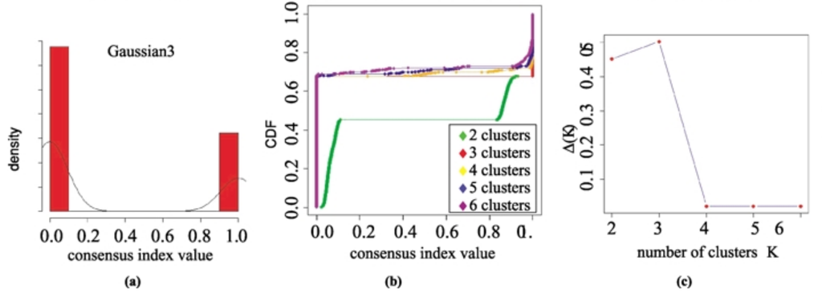

Next, let’s look at a simulated example where there are 5 groups.

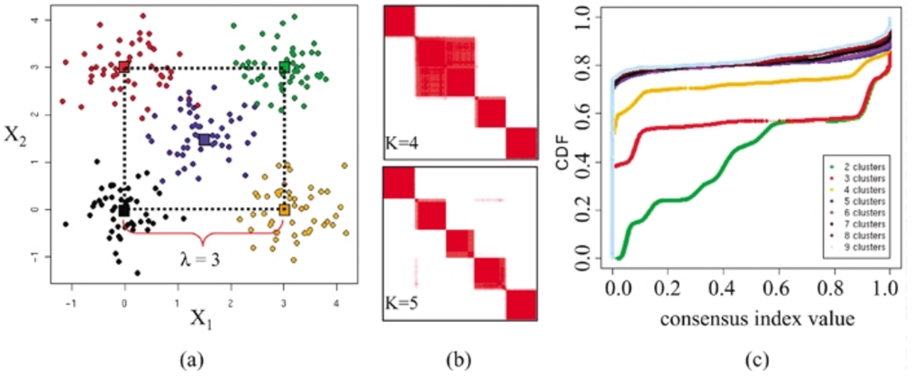

Notice how the consensus matrix at *k* = 5 looks “cleaner” than the one for *k* = 4 and there appears to be an increase in the area under the CDF between *k* = 4 and *k* = 5.

*All figures from [Monti et al. (2003)](https://doi.org/10.1023/A:1023949509487).*

Consensus clustering is one way to help you determine the number of clusters in your data, but it is not the only methodology available. Check out the Data Novia course [*Cluster Validation Essentials* by Alboukadel Kassambara](https://www.datanovia.com/en/courses/cluster-validation-essentials/) for a deeper dive.

[output not shown]

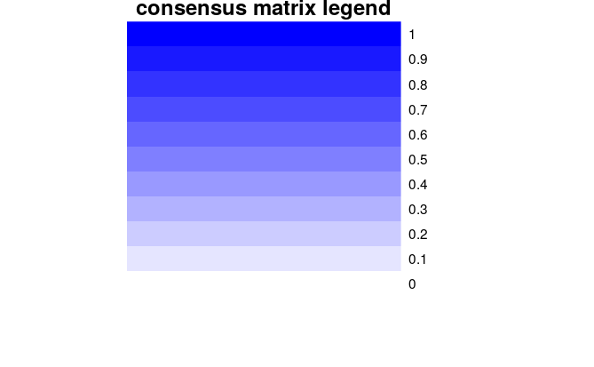

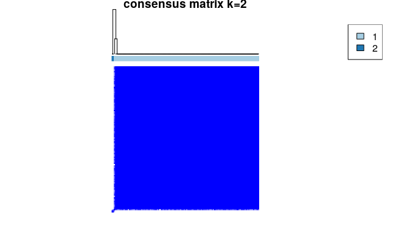

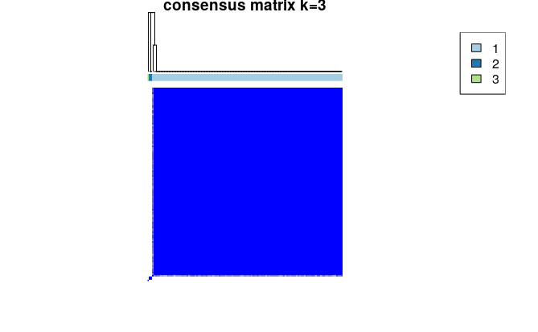

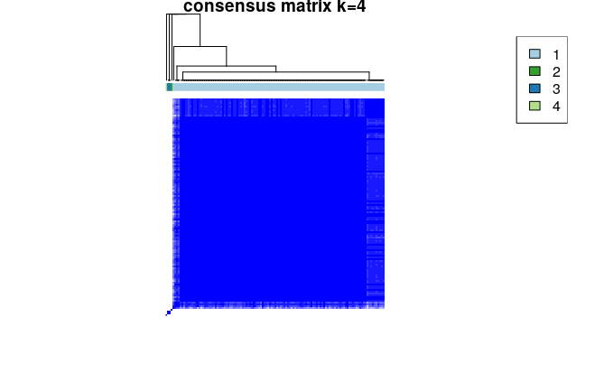

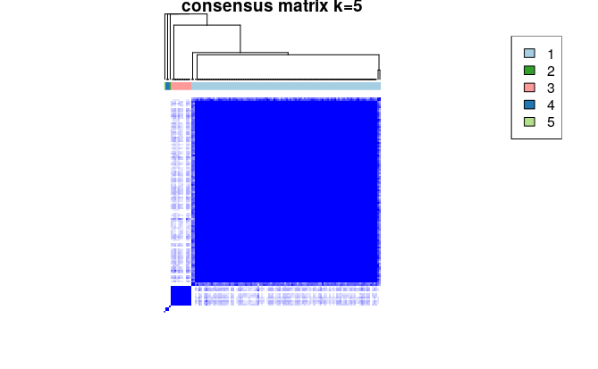

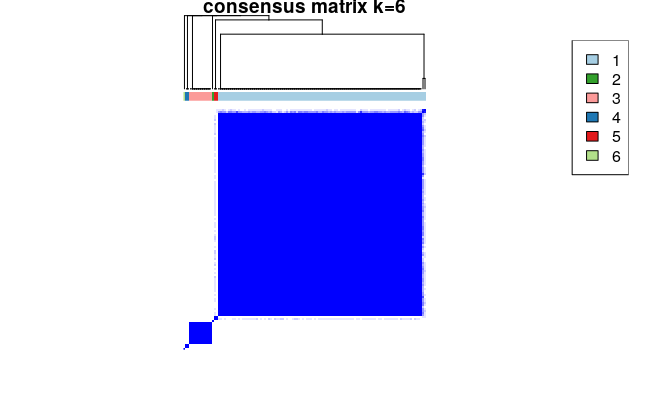

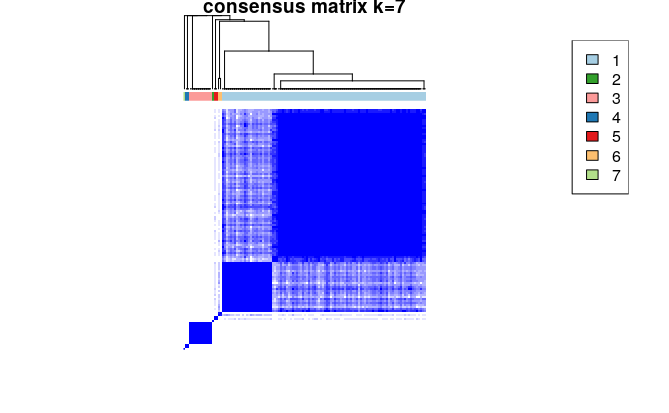

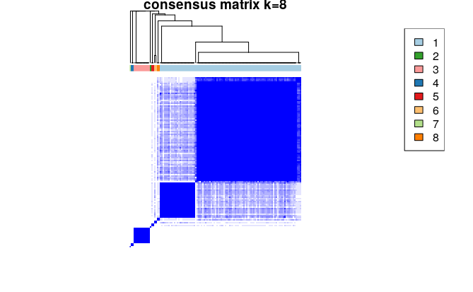

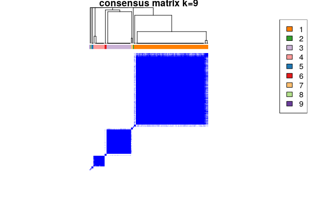

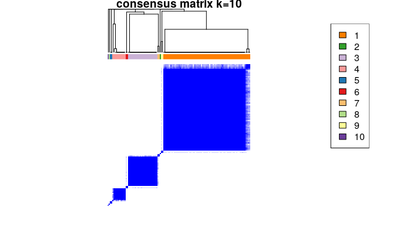

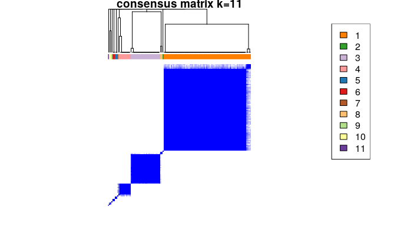

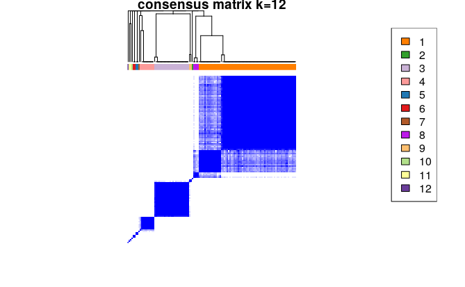

[6 more figures not shown]

```r
cc_results <- ConsensusClusterPlus(rnaseq_mat,
                                   maxK = 15,
                                   # Setting this seed is necessary for the
                                   # results to be reproducible
                                   seed = 2020,
                                   innerLinkage = "average",
                                   finalLinkage = "average",
                                   distance = "pearson")
```

Our results are not as clean as the simulated data (surprise, surprise)! We see an increase on the delta plot in several places: *k* = 5, *k* = 7, *k* = 9, and *k* = 12.

If we look at the tracking plot that tells us how the samples group together and the consensus index plots, we can see 3 main clusters that arise around *k* = 9 but we could also make an argument for the two groups that show up at *k* 5 through 8.

We’ll move forward with the *k* = 9 labels, but we hope you appreciate that determining the number clusters is not an easy problem!

Let’s take a look at the class labels for *k* = 9.

```r
# table() creates a contingency table of counts
table(cc_results[[9]]$consensusClass)
```

```
 1  2  3  4  5  6  7  8  9
76  1 25 11  2  2  2  1  1
```

(Note: the numbering of the clusters is arbitrary here.)

A cluster of a few samples may not be that helpful in reaching our analysis goals! Now to extract the samples in the clusters of interest.

```r
cc_cluster_labels <- cc_results[[9]]$consensusClass
head(cc_cluster_labels)
```

```
BS_09Z7TC35 BS_1AYRM596 BS_1BWP5MCT BS_1QXEC43H BS_1TWCV047 BS_2SFTWNVE
          1           1           2           3           1           1
```

### Compare clustering results to external metadata labels

As mentioned at the top of the notebook, there are multiple medulloblastoma molecular subtypes The subtype classification largely relies on gene expression data. A [medulloblastoma subtype classifier](https://github.com/d3b-center/medullo-classifier-package), which is an example of *supervised machine learning*, has been applied to the medulloblastoma samples included in OpenPBTA. How do the subtype labels from this classifier (in the `molecular_subtype` column of our sample metadata) stack up to the clusters we identified with unsupervised methods?

Let’s first make a data frame that holds the subtype labels. We can use this to compare our unsupervised clustering results to the subtype labels.

```r
subtype_df <- clinical_df %>%
  select(Kids_First_Biospecimen_ID, molecular_subtype)
```

Add the consensus clustering labels.

```r
# Create a data frame that contains the consensus cluster results and join
# it with the data frame of molecular subtype labels
cc_df <- data.frame(cc_cluster_labels) %>%
  rownames_to_column("Kids_First_Biospecimen_ID") %>%
  inner_join(subtype_df, by = "Kids_First_Biospecimen_ID")
```

Do the consensus clustering results agree with the molecular subtype labels?

```r
table(cc_df$cc_cluster_labels, cc_df$molecular_subtype)
```

```
    Group3 Group4 SHH WNT
  1     13     55   6   2
  2      1      0   0   0
  3      0      7  18   0
  4      1      2   0   8
  5      0      0   1   1
  6      0      0   2   0
  7      0      2   0   0
  8      0      0   1   0
  9      0      1   0   0
```

The subtype labels we have from the classifier largely agree with our unsupervised results, but it’s not perfect. It’s worth noting that the classifier uses different features than what we covered here.

In the next notebook, we’ll look at other ways to examine the overall structure in our data!